# NBA PLAYERS SALARY ANALYSIS

Kevin Andrian Suryanto

# Abstract

A common person would assume that the success of an NBA player’s career is directly correlated with how much points they can score, and therefore would earn more salary if they have more points. However, points scored by an NBA player typically aren’t the only measure of success. Moreover, although some NBA players are considered more successful than others, some of those players identified as less successful earn more than some players that are indentified as more successful.

# Research Question

What affects an NBA player’s salary? What are the biggest contributing factors to a player’s salary? Does more playing time result in higher salary?

# Packages needed

```r
library(magrittr)
library(dplyr)
library(tidyverse)
library(DataComputing)
```

# Data for Analysis

```r
nbastats <- read.csv("nba_2017_players_stats_combined.csv")
nbasalary <- read.csv("nba_2017_salary.csv")
```

These 2 datasets are obtained from Kaggle (https://www.kaggle.com/noahgift/social-power-nba), an online community of data scientists and machine learning practitioners. The data is collected by the NBA and uploaded by Noah Gift in 2017. This data is used in several studies for the IBM Developerworks: “Explore valuation and attendance using data science and machine learning” and “Exploring the individual NBA players.”

### Variables

- Rk = Player’s rank in terms of points per game
- PLAYER = Player’s name
- POSITION = Player’s position
- AGE = Player’s age
- MP = Minutes played
- FG = Field goals made per game
- FGA = Field goals attempted per game
- FG. = Field goal % (made over attempted)
- X3P = 3-point field goals made per game
- X3PA = 3-point field goals attempted per game
- X3P. = 3-point field goal % (made over attempted)
- X2P = 2-point field goals made per game
- X2PA = 2-point field goals attempted per game
- X2P. = 2-point field goal % (made over attempted)
- eFG. = Effective field goal %
- FT = Free throws made per game
- FTA = Free throws attempted per game
- FT. = Free throw % (made over attempted)
- ORB = Offensive rebounds per game
- DRB = Defensive rebounds per game
- TRB = Total rebounds per game
- STL = Steals per game
- BLK = Blocks per game
- TOV = Turnovers per game
- PF = Personal fouls committed per game
- Points = Points per game
- TEAM = Player’s team abbreviation
- GP = Number of games played
- MPG = Minutes played per game]
- ORPM = Offensive real plus-minus per game
- DRPM = Defensive real plus-minus per game
- RPM = Real plus-minus per game
- WINS_RPM = An estimate of the number of wins a player has contributed to his team’s win total on the season
- PIE = Player’s impact estimate (a player’s impact on each individual game they play)
- PACE = Estimate of the number of possessions per 48 minutes
- W = Number of wins
- SALARY = Amount of yearly salary (in $)

### Glimpse of Data

```r
head(nbastats)
```

|  | X | Rk | PLAYER | POSITION | AGE | MP | FG | FGA | FG. | X3P | X3PA | X3P. | X2P | X2PA | X2P. | eFG. | FT | FTA | FT. | ORB | DRB | TRB | AST | STL | BLK | TOV | PF | POINTS | TEAM | … |
| --- | --- | --- | --- | --- | --- | --- | --- | --- | --- | --- | --- | --- | --- | --- | --- | --- | --- | --- | --- | --- | --- | --- | --- | --- | --- | --- | --- | --- | --- | --- |
| 1 | 0 | 1 | Russell Westbrook | PG | 28 | 34.6 | 10.2 | 24.0 | 0.425 | 2.5 | 7.2 | 0.343 | 7.7 | 16.8 | 0.459 | 0.476 | 8.8 | 10.4 | 0.845 | 1.7 | 9.0 | 10.7 | 10.4 | 1.6 | 0.4 | 5.4 | 2.3 | 31.6 | OKC | … |
| 2 | 1 | 2 | James Harden | PG | 27 | 36.4 | 8.3 | 18.9 | 0.440 | 3.2 | 9.3 | 0.347 | 5.1 | 9.6 | 0.530 | 0.525 | 9.2 | 10.9 | 0.847 | 1.2 | 7.0 | 8.1 | 11.2 | 1.5 | 0.5 | 5.7 | 2.7 | 29.1 | HOU | … |
| 3 | 2 | 3 | Isaiah Thomas | PG | 27 | 33.8 | 9.0 | 19.4 | 0.463 | 3.2 | 8.5 | 0.379 | 5.8 | 10.9 | 0.528 | 0.546 | 7.8 | 8.5 | 0.909 | 0.6 | 2.1 | 2.7 | 5.9 | 0.9 | 0.2 | 2.8 | 2.2 | 28.9 | BOS | … |
| 4 | 3 | 4 | Anthony Davis | C | 23 | 36.1 | 10.3 | 20.3 | 0.505 | 0.5 | 1.8 | 0.299 | 9.7 | 18.6 | 0.524 | 0.518 | 6.9 | 8.6 | 0.802 | 2.3 | 9.5 | 11.8 | 2.1 | 1.3 | 2.2 | 2.4 | 2.2 | 28.0 | NO | … |
| 5 | 4 | 5 | DeMar DeRozan | SG | 27 | 35.4 | 9.7 | 20.9 | 0.467 | 0.4 | 1.7 | 0.266 | 9.3 | 19.2 | 0.484 | 0.477 | 7.4 | 8.7 | 0.842 | 0.9 | 4.3 | 5.2 | 3.9 | 1.1 | 0.2 | 2.4 | 1.8 | 27.3 | TOR | … |
| 6 | 5 | 6 | DeMarcus Cousins | C | 26 | 34.2 | 9.0 | 19.9 | 0.452 | 1.8 | 5.0 | 0.361 | 7.2 | 14.8 | 0.483 | 0.498 | 7.2 | 9.3 | 0.772 | 2.1 | 8.9 | 11.0 | 4.6 | 1.4 | 1.3 | 3.7 | 3.9 | 27.0 | NO/SAC | … |

```r
head(nbasalary)
```

|  | NAME | POSITION | TEAM | SALARY |
| --- | --- | --- | --- | --- |
| 1 | LeBron James | SF | Cleveland Cavaliers | 30963450 |
| 2 | Mike Conley | PG | Memphis Grizzlies | 26540100 |
| 3 | Al Horford | C | Boston Celtics | 26540100 |
| 4 | Dirk Nowitzki | PF | Dallas Mavericks | 25000000 |
| 5 | Carmelo Anthony | SF | New York Knicks | 24559380 |
| 6 | Damian Lillard | PG | Portland Trail Blazers | 24328425 |

The variable “POSITION” and “TEAM” will be deleted from nbasalary since “POSITION” and “TEAM” are already present in the nbastats dataset. The first colum will be deleted from nbastats since it is unnecessary. The two datasets will be joined by the player’s name. Duplicates of NBA players (if any) will also be removed.

```r
nbastats <- nbastats[,-1]
nbasalary <- nbasalary[,-2][,-2]
nba <- nbastats %>%
  left_join(nbasalary, by = c("PLAYER" = "NAME"))
```

```
Column `PLAYER`/`NAME` joining factors with different levels, coercing to character vector
```

```r
nba = nba[!duplicated(nba$PLAYER),]
head(nba)
```

|  | Rk | PLAYER | POSITION | AGE | MP | FG | FGA | FG. | X3P | X3PA | X3P. | X2P | X2PA | X2P. | eFG. | FT | FTA | FT. | ORB | DRB | TRB | AST | STL | BLK | TOV | PF | POINTS | TEAM | GP | … |
| --- | --- | --- | --- | --- | --- | --- | --- | --- | --- | --- | --- | --- | --- | --- | --- | --- | --- | --- | --- | --- | --- | --- | --- | --- | --- | --- | --- | --- | --- | --- |
| 1 | 1 | Russell Westbrook | PG | 28 | 34.6 | 10.2 | 24.0 | 0.425 | 2.5 | 7.2 | 0.343 | 7.7 | 16.8 | 0.459 | 0.476 | 8.8 | 10.4 | 0.845 | 1.7 | 9.0 | 10.7 | 10.4 | 1.6 | 0.4 | 5.4 | 2.3 | 31.6 | OKC | 81 | … |
| 2 | 2 | James Harden | PG | 27 | 36.4 | 8.3 | 18.9 | 0.440 | 3.2 | 9.3 | 0.347 | 5.1 | 9.6 | 0.530 | 0.525 | 9.2 | 10.9 | 0.847 | 1.2 | 7.0 | 8.1 | 11.2 | 1.5 | 0.5 | 5.7 | 2.7 | 29.1 | HOU | 81 | … |
| 3 | 3 | Isaiah Thomas | PG | 27 | 33.8 | 9.0 | 19.4 | 0.463 | 3.2 | 8.5 | 0.379 | 5.8 | 10.9 | 0.528 | 0.546 | 7.8 | 8.5 | 0.909 | 0.6 | 2.1 | 2.7 | 5.9 | 0.9 | 0.2 | 2.8 | 2.2 | 28.9 | BOS | 76 | … |
| 4 | 4 | Anthony Davis | C | 23 | 36.1 | 10.3 | 20.3 | 0.505 | 0.5 | 1.8 | 0.299 | 9.7 | 18.6 | 0.524 | 0.518 | 6.9 | 8.6 | 0.802 | 2.3 | 9.5 | 11.8 | 2.1 | 1.3 | 2.2 | 2.4 | 2.2 | 28.0 | NO | 75 | … |
| 5 | 5 | DeMar DeRozan | SG | 27 | 35.4 | 9.7 | 20.9 | 0.467 | 0.4 | 1.7 | 0.266 | 9.3 | 19.2 | 0.484 | 0.477 | 7.4 | 8.7 | 0.842 | 0.9 | 4.3 | 5.2 | 3.9 | 1.1 | 0.2 | 2.4 | 1.8 | 27.3 | TOR | 74 | … |
| 6 | 6 | DeMarcus Cousins | C | 26 | 34.2 | 9.0 | 19.9 | 0.452 | 1.8 | 5.0 | 0.361 | 7.2 | 14.8 | 0.483 | 0.498 | 7.2 | 9.3 | 0.772 | 2.1 | 8.9 | 11.0 | 4.6 | 1.4 | 1.3 | 3.7 | 3.9 | 27.0 | NO/SAC | 72 | … |

### Data Description

The dataset “nbastats”" shows statistics for NBA players’ on-court performances in the 2016-2017 season. The dataset “nbasalary” shows NBA players’ salaries in the 2016-2017 season. The combined dataset has 446 cases. Each case represents an NBA player.

```r
nrow(nba)
```

```
[1] 446
```

# How much does an NBA player’s salaries vary?

```r
summary(nba$SALARY)
```

```
    Min.  1st Qu.   Median     Mean  3rd Qu.     Max.
   31969  2286962  5000000  7415807 11237182 30963450
    NA's
     111
```

```r
attach(nba)
#Top 5 highest earning players
nba %>%
  select(PLAYER,SALARY) %>%
  arrange(desc(SALARY)) %>%
  slice(1:5)
```

| PLAYER | SALARY |
| --- | --- |
| LeBron James | 30963450 |
| Mike Conley | 26540100 |
| Al Horford | 26540100 |
| Russell Westbrook | 26500000 |
| James Harden | 26500000 |

```r
#Top 5 lowest earning players
nba %>%
  select(PLAYER,SALARY) %>%
  arrange(SALARY) %>%
  slice(1:5)
```

| PLAYER | SALARY |
| --- | --- |
| Pierre Jackson | 31969 |
| Jarell Eddie | 57672 |
| Anthony Brown | 57672 |
| Jarrett Jack | 57672 |
| Alonzo Gee | 57672 |

# Does an NBA player’s points result in higher salary?

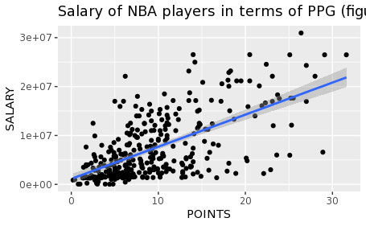

```r
ggplot(data=nba,aes(x=POINTS,y=SALARY))+geom_point() + stat_smooth(method=lm) + ggtitle("Salary of NBA players in terms of PPG (figure 1.1)")
```

When referring to figure 1.1, there seems to be an upward trend which shows that higher points per game typically results in higher salary although it’s not for all cases.

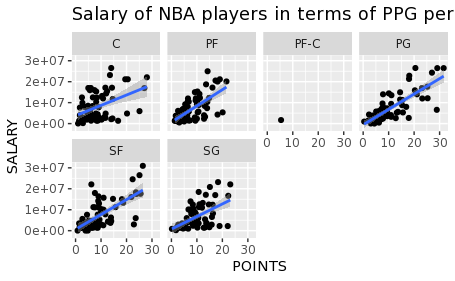

```r
ggplot(data=nba,aes(x=POINTS,y=SALARY))+geom_point()+facet_wrap(~POSITION,ncol=4) + stat_smooth(method=lm) + ggtitle("Salary of NBA players in terms of PPG per position (figure 1.2)")
```

## Assists per game

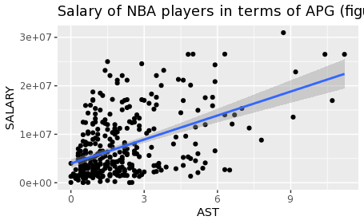

```r
ggplot(data=nba,aes(x=AST,y=SALARY))+geom_point() + stat_smooth(method=lm) + ggtitle("Salary of NBA players in terms of APG (figure 2.1)")
```

We can obseve that there is an upward trend in salary in terms of assists per game.

## Rebounds per game

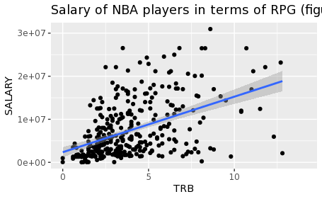

```r
ggplot(data=nba,aes(x=TRB,y=SALARY))+geom_point() + stat_smooth(method=lm) + ggtitle("Salary of NBA players in terms of RPG (figure 2.2)")
```

We can obseve that there is an upward trend in salary in terms of rebounds per game.

## Steals per game

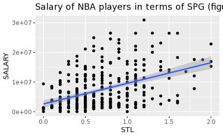

```r
ggplot(data=nba,aes(x=STL,y=SALARY))+geom_point() + stat_smooth(method=lm) + ggtitle("Salary of NBA players in terms of SPG (figure 2.3)")
```

We can obseve that there is a slight upward trend in salary in terms of steals per game although it is not significant.

## Blocks per game

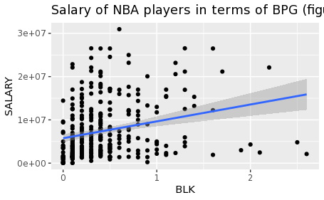

```r
ggplot(data=nba,aes(x=BLK,y=SALARY))+geom_point() + stat_smooth(method=lm) + ggtitle("Salary of NBA players in terms of BPG (figure 1.1)")
```

We can obseve that there is a slight upward trend in salary in terms of blocks per game although it is not significant.

## Minutes played per game

```r
ggplot(data=nba,aes(x=MP,y=SALARY))+geom_point() + stat_smooth(method=lm) + ggtitle("Salary of NBA players in terms of MPG (figure 2.5)")
```

[output not shown]

We can obseve that there is an upward trend in salary in terms of minutes played per game.

However, although all of these key NBA stats graphically show an increasing trend, we will further perform a simple linear regression test the significance of these NBA statistic measures.

## Simple Linear Regression

Linear regression models are used to show or predict the relationship between two variables or factors. We will fit salary as the response variable and use number of points, assists, rebounds, steals, blocks, and minutes played as the predictors.

```r
summary(model)
```

```
Call:
lm(formula = SALARY ~ POINTS + AST + TRB + STL + BLK + MP)

Residuals:
      Min        1Q    Median        3Q       Max
-14135984  -3006316   -381368   2645436  16903234

Coefficients:
            Estimate Std. Error t value Pr(>|t|)
(Intercept)  -304269     812635  -0.374 0.708332
POINTS        394863      93147   4.239 2.92e-05 ***
AST           513414     227989   2.252 0.024988 *
TRB           683807     186499   3.667 0.000287 ***
STL          -803698    1093938  -0.735 0.463057
BLK         -1213719     920610  -1.318 0.188294
MP             57399      73645   0.779 0.436302
---
Signif. codes:
0 ‘***’ 0.001 ‘**’ 0.01 ‘*’ 0.05 ‘.’ 0.1 ‘ ’ 1

Residual standard error: 4958000 on 328 degrees of freedom
  (111 observations deleted due to missingness)
Multiple R-squared:  0.4336,    Adjusted R-squared:  0.4233
F-statistic: 41.86 on 6 and 328 DF,  p-value: < 2.2e-16
```

From the p-value results above, we are 95% confident that number of points, assist, and rebound have a significant relationship with a player’s salary. However, we fail to reject the null hypothesis that steals, blocks, and minutes player significantly affect a player’s salary.

# Conclusion

From the graphical and linear regression observations, we can conclude that the number of points per game by an NBA player significantly affects an NBA player’s salary. Moreover, other key important factors such as number of assists and rebounds also significantly affect a player’s salary. Some people may say that more playing time (or minutes played) have higher salaries. However, although our graph shows that there is a positive relationship between minutes played and salary, the linear regression output shows that the effect of minutes played is not significant to salary.